# Doing big data with Spark Pt. 3

# (sort of) Big data

We will be using publicly available data from Medicare to illustrate how `sparklyr` makes large analysis possible, even just on our laptops.

## Medicare Payments Data

This dataset includes data about payments for services for Medicare providers during the 2015 calendar year. There is one row per provider/HCPCS code and several aggregate columns describing the number of times the provider billed for the code, average submitted amount, average paid amount, etc.

[This page](https://www.cms.gov/Research-Statistics-Data-and-Systems/Statistics-Trends-and-Reports/Medicare-Provider-Charge-Data/Physician-and-Other-Supplier2015.html) provides more info and download links.

Make sure to download the tab-delimited file. It is rather hefty (~2GB uncompressed), so be prepared to wait when downloading and uncompressing.

After you unzip the file, rename it to `medicare_partb_2015.txt` and move it to the same directory as this notebook.

```r
library(ggplot2)
source('spark_init.R')
```

## Caching

Since Spark evaluates in a lazy manner, each time you execute an action it will run the entire chain of commands, including reading the data from its source. Therefore, if you are calling several actions on a Dataframe, it will re-load the data each time.

Caching allows Spark to process the whole Dataframe once and then save that into memory on the cluster. There are trade-offs with caching, and the general rules are:

- If you are re-using a Dataframe multiple times, try caching it
- If your data is really huge, and you only need small portion of it, do not cache.

You don’t notice it will small data, but `sparklyr` caches all tables into memory by default (I don’t like this). Set `memory = F` with `spark_read_` functions to disable caching.

```r
partb <- spark_read_csv(sc, 'partb', 'medicare_partb_2015.txt', delimiter = '\t', memory = F)
```

```r
file.info('medicare_partb_2015.txt')$size
```

```
## [1] 2160155698
```

```r
pryr::object_size(partb)
```

```
## 10.5 kB
```

This will take a while, or blow up (depending on how much RAM you have)

```r
partb_cached <- spark_read_csv(sc, 'partb_cached', 'medicare_partb_2015.txt', delimiter = '\t')
```

We don’t want to cache anyway, because normally an analysis will be selecting certain columns, joining and performing aggregations first. Once we get a nice clean Dataframe for analysis, then we can cache it (especially if its being used for ML).

## Explore the data

```r
colnames(partb)
```

```
##  [1] "npi"                              "nppes_provider_last_org_name"
##  [3] "nppes_provider_first_name"        "nppes_provider_mi"
##  [5] "nppes_credentials"                "nppes_provider_gender"
##  [7] "nppes_entity_code"                "nppes_provider_street1"
##  [9] "nppes_provider_street2"           "nppes_provider_city"
## [11] "nppes_provider_zip"               "nppes_provider_state"
## [13] "nppes_provider_country"           "provider_type"
## [15] "medicare_participation_indicator" "place_of_service"
## [17] "hcpcs_code"                       "hcpcs_description"
## [19] "hcpcs_drug_indicator"             "line_srvc_cnt"
## [21] "bene_unique_cnt"                  "bene_day_srvc_cnt"
## [23] "average_Medicare_allowed_amt"     "average_submitted_chrg_amt"
## [25] "average_Medicare_payment_amt"     "average_Medicare_standard_amt"
```

```r
head(partb)
```

```
## # Source:   lazy query [?? x 26]
## # Database: spark_connection
##          npi
##        <int>
## 1          1
## 2 1003000126
## 3 1003000126
## 4 1003000126
## 5 1003000126
## 6 1003000126
## # ... with 25 more variables: nppes_provider_last_org_name <chr>,
## #   nppes_provider_first_name <chr>, nppes_provider_mi <chr>,
## #   nppes_credentials <chr>, nppes_provider_gender <chr>,
## #   nppes_entity_code <chr>, nppes_provider_street1 <chr>,
## #   nppes_provider_street2 <chr>, nppes_provider_city <chr>,
## #   nppes_provider_zip <chr>, nppes_provider_state <chr>,
## #   nppes_provider_country <chr>, provider_type <chr>,
## #   medicare_participation_indicator <chr>, place_of_service <chr>,
## #   hcpcs_code <chr>, hcpcs_description <chr>, hcpcs_drug_indicator <chr>,
## #   line_srvc_cnt <dbl>, bene_unique_cnt <int>, bene_day_srvc_cnt <int>,
## #   average_Medicare_allowed_amt <dbl>, average_submitted_chrg_amt <dbl>,
## #   average_Medicare_payment_amt <dbl>,
## #   average_Medicare_standard_amt <dbl>
```

```r
sdf_nrow(partb)
```

```
## [1] 9497892
```

```r
partb %>% select(npi) %>% distinct() %>% count()
```

```
## # Source:   lazy query [?? x 1]
## # Database: spark_connection
##        n
##    <dbl>
## 1 968418
```

```r
partb %>% select(npi, hcpcs_code) %>% distinct() %>% count()
```

```
## # Source:   lazy query [?? x 1]
## # Database: spark_connection
##         n
##     <dbl>
## 1 9226141
```

Turns out there can be multiple rows per provider/HCPCS code (due to place of service), so we need to perform some aggregation. Let’s also remove that annoying copyright line.

```r
partb %>% count(place_of_service)
```

```
## # Source:   lazy query [?? x 2]
## # Database: spark_connection
##   place_of_service       n
##              <chr>   <dbl>
## 1             <NA>       1
## 2                F 3814128
## 3                O 5683763
```

```r
partb_agg <- partb %>%
  filter(npi != 1) %>%
  group_by(npi, hcpcs_code, provider_type) %>%
  summarise(line_srvc_cnt = sum(line_srvc_cnt),
            average_submitted_chrg_amt = mean(average_submitted_chrg_amt)) %>%
  ungroup()
```

Remember, that ^ didn’t do anything! It will process only when you call an action.

```r
head(partb_agg)
```

```
## # Source:   lazy query [?? x 5]
## # Database: spark_connection
##          npi hcpcs_code   provider_type line_srvc_cnt
##        <int>      <chr>           <chr>         <dbl>
## 1 1003000134      88323       Pathology            11
## 2 1003000142      20610  Anesthesiology            19
## 3 1003000142      99213  Anesthesiology            67
## 4 1003000407      99220 Family Practice            64
## 5 1003000407      99233 Family Practice           281
## 6 1003000407      99239 Family Practice           242
## # ... with 1 more variables: average_submitted_chrg_amt <dbl>
```

```r
partb_agg %>% select(npi, hcpcs_code) %>% distinct() %>% count()
```

```
## # Source:   lazy query [?? x 1]
## # Database: spark_connection
##         n
##     <dbl>
## 1 9226140
```

## Plotting

One place where using `sparklyr` gets tricky is with plotting. When plotting, you need to collect all your data to the R session, so you have to perform some aggregations first before pulling it down. The difficult plots are those that summarise distribution (histograms, boxplots, etc.) because usually `ggplot2` does the computing for you.

Let’s look at the distribution of provider types

```r
provider_type <- partb_agg %>%
  group_by(provider_type) %>%
  summarise(n = n_distinct(npi)) %>%
  collect()
head(provider_type)
```

```
## # A tibble: 6 x 2
##                             provider_type     n
##                                     <chr> <dbl>
## 1                              Cardiology 20656
## 2                         Sports Medicine   832
## 3                            Chiropractic 35429
## 4                     Clinical Laboratory  2862
## 5 Independent Diagnostic Testing Facility  2741
## 6          Interventional Pain Management  1675
```

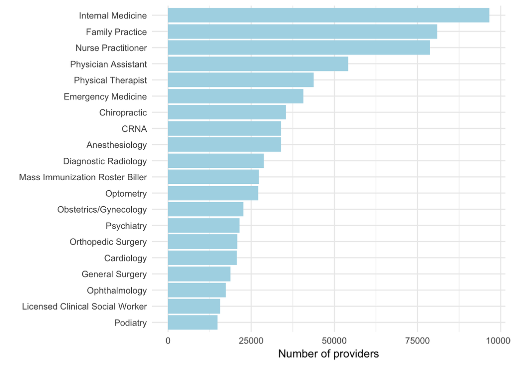

```r
provider_type %>%
  top_n(20) %>%
  ggplot(aes(x = reorder(provider_type, n), y = n)) +
    geom_bar(stat = 'identity', fill = 'light blue') +
    xlab('') + ylab('Number of providers') +
    theme_minimal() + coord_flip()
```

Now let’s see the distribution of submitted amounts for the most frequent HCPCS codes. We would have to compute the summary stats ourselves because the data is too big to fit in memory. Luckily, our friend Edgar Ruiz has a handy package to create plots from database (or Spark) dplyr backends:

- dbplot

```r
hcpcs_count <- partb_agg %>% count(hcpcs_code) %>% collect()
top5_hcpcs <- hcpcs_count %>% top_n(5, n)
```

```
## na.rm not needed in SQL: NULL are always droppedFALSE
## na.rm not needed in SQL: NULL are always droppedFALSE
```

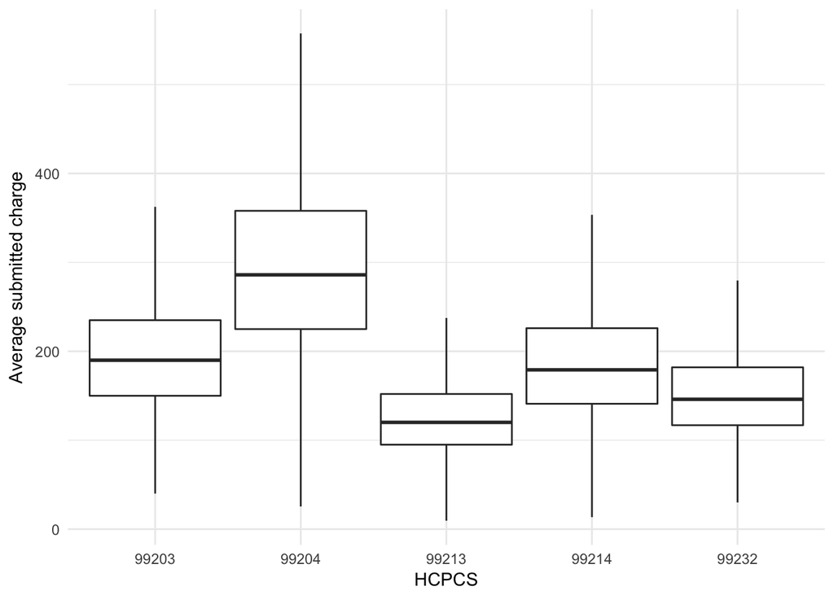

```r
library(dbplot)
partb_agg %>%
  filter(hcpcs_code %in% top5_hcpcs$hcpcs_code) %>%
  dbplot_boxplot(hcpcs_code, average_submitted_chrg_amt) +
  xlab('HCPCS') + ylab('Average submitted charge') +
  theme_minimal()
```

## Homework

See if all we did in this notebook would be possible with vanilla R or `dplyr` without Spark :)